# Atrium University ML Tools

Introduction to Linear Regression: Try It In R!

[figure not shown]

# Trying it in R:

Now that we know some of the common problems that can be solved using linear regerssion tools, we can try implmenting it! Nearly every statistical software package available can do linear regression. We will outline how it can be done using R. *For directions on how to install and use R, see the “Using R” tutorial on the Wookie*.

This document contains R-code and output associated with the modeling process. If you have questions about how the models are built or how code works, email paul@atrium.ai.

Consider the following scenario. You are trying to determine whether or not having a garage impacts the sales price of a home. You collect data on home sales in your city (which, in this case, happens to be Grand Junction, Colorado). Then, you plan to analyze it in R via the following steps:

```r
#reads in the data from a .csv file (generally easiest way to get into R)
mcdat.full <- read.csv('mcdat.csv',header = TRUE)
mcdat.full$Garage <- ifelse(mcdat.full$Garage.sqft %in% c('y','Y'),1,0)
mcdat <- mcdat.full[1:145,]
mcdat.predict <- mcdat.full[146:163,]
dim(mcdat) #tells us we have 163 observations on 38 variables
```

```
## [1] 145  39
```

Let’s take a look at the data:

```r
datatable(mcdat[,-c(6,11,12)], options = list(pageLength = 5, scrollX = 75)) #returns the first 10 rows of data
```

|  | PROPERTYUSE | PARCELNUMBER | SITUS_ADDRESS | NEIGHBORHOOD | Account.Number | SIBPARCEL | TITLENO | NEIGHBORHOOD.Desc. | Date | Price | Verified | Validity | Reception | Doc..Type | Prop.Type | SALE_PROPERTYTYPE | SALE_DOCUMENTTYPEVALUE | ECONOMICAREA | Prop.Use.Desc. | LATITUDE | LONGITUDE | ACRES | Total_HeatedSqFtV | Price.by.Heated.SQFT | Book | Page | numberofBuildings | ArchConcat | Min_EFFECTIVEYEARBUILT | … |
| --- | --- | --- | --- | --- | --- | --- | --- | --- | --- | --- | --- | --- | --- | --- | --- | --- | --- | --- | --- | --- | --- | --- | --- | --- | --- | --- | --- | --- | --- | --- |
| 1 | 1003 | 2697-074-21-014 | 1278 SANTA FE CIR | 66.12 | R007713 |  |  | Santa Fe Townhomes | 9/10/2010 | 174500 | False | Q | 2545499 | WD | IMPROVED | I | WARRANTY DEED | Fruita / East 18 to 22 Rd | Townhouse | 39.16743204 | -108.7475456 | 0.229 | 1332 | 131 |  |  | 1 | -TOWNHSE 1-Sty- | 2004 | … |
| 2 | 1003 | 2697-074-21-017 | 1296 SANTA FE CIR | 66.12 | R007716 |  |  | Santa Fe Townhomes | 8/31/2011 | 178000 | False | Q | 2583257 | DEED | IMPROVED | I | DEED | Fruita / East 18 to 22 Rd | Townhouse | 39.16744513 | -108.7467948 | 0.194 | 1332 | 133.6 |  |  | 1 | -TOWNHSE 1-Sty- | 2004 | … |
| 3 | 1003 | 2697-092-32-019 | 1120 PRIMROSE LN | 67.11 | R009034 |  |  | Village @ Country Cr | 12/20/2011 | 240000 | False | Q | 2595767 | WDJT | IMPROVED | I | WARRANTY DEED JOINT TENANTS | Fruita / East 18 to 22 Rd | Townhouse | 39.17271616 | -108.7179032 | 0.059 | 1559 | 153.9 |  |  | 1 | -TOWNHSE 1-Sty- | 2002 | … |
| 4 | 1003 | 2697-092-32-025 | 1128 PRIMROSE LN | 67.11 | R009040 |  |  | Village @ Country Cr | 12/13/2010 | 186000 | False | Q | 2556871 | WD | IMPROVED | I | WARRANTY DEED | Fruita / East 18 to 22 Rd | Townhouse | 39.17267743 | -108.7173309 | 0.047 | 1244 | 149.5 |  |  | 1 | -TOWNHSE 1-Sty- | 2003 | … |
| 5 | 1003 | 2697-092-32-025 | 1128 PRIMROSE LN | 67.11 | R009040 |  |  | Village @ Country Cr | 12/9/2011 | 159500 | False | Q | 2594303 | WD | IMPROVED | I | WARRANTY DEED | Fruita / East 18 to 22 Rd | Townhouse | 39.17267743 | -108.7173309 | 0.047 | 1244 | 128.2 |  |  | 1 | -TOWNHSE 1-Sty- | 2003 | … |
| 6 | 1003 | 2697-092-33-012 | 1111 PRIMROSE LN | 67.11 | R009058 |  |  | Village @ Country Cr | 2/21/2012 | 190000 | False | Q | 2600978 | WDJT | IMPROVED | I | WARRANTY DEED JOINT TENANTS | Fruita / East 18 to 22 Rd | Townhouse | 39.17336415 | -108.7185022 | 0.06 | 1523 | 124.8 |  |  | 1 | -TOWNHSE 1-Sty- | 1998 | … |
| 7 | 1003 | 2697-092-52-015 | 1143 PRIMROSE LN | 67.11 | R009121 |  |  | Village @ Country Cr | 7/15/2010 | 240000 | False | Q | 2539327 | WDJT | IMPROVED | I | WARRANTY DEED JOINT TENANTS | Fruita / East 18 to 22 Rd | Townhouse | 39.17349815 | -108.7164678 | 0.059 | 1567 | 153.2 |  |  | 1 | -TOWNHSE 1-Sty- | 2003 | … |
| 8 | 1003 | 2697-092-52-018 | 1149 PRIMROSE LN #A | 67.11 | R009124 |  |  | Village @ Country Cr | 5/11/2012 | 220000 | False | Q | 2610678 | WD | IMPROVED | I | WARRANTY DEED | Fruita / East 18 to 22 Rd | Townhouse | 39.17381585 | -108.7160536 | 0.061 | 1559 | 141.1 |  |  | 1 | -TOWNHSE 1-Sty- | 2004 | … |
| 9 | 1003 | 2697-092-62-014 | 1115 SUNROSE LN #3-13 | 67.11 | R009202 | 0000-000-00-000 |  | Village @ Country Cr | 12/5/2011 | 233000 | False | Q | 2594532 | WD | IMPROVED | I | WARRANTY DEED | Fruita / East 18 to 22 Rd | Townhouse | 39.17487077 | -108.7181709 | 0.062 | 1597 | 145.9 |  |  | 1 | -TOWNHSE 1-Sty- | 2007 | … |
| 10 | 1003 | 2697-092-64-009 | 1210 SUNROSE LN #3-31 | 67.11 | R009230 | 0000-000-00-000 |  | Village @ Country Cr | 8/24/2010 | 235000 | False | Q | 2544322 | WDJT | IMPROVED | I | WARRANTY DEED JOINT TENANTS | Fruita / East 18 to 22 Rd | Townhouse | 39.17451358 | -108.7165997 | 0.06 | 1367 | 171.9 |  |  | 1 | -TOWNHSE 1-Sty- | 2005 | … |

[output cut: 135 more lines]

Every dataset contains variables that are not necessarily good predictors. In this case, we filter out all the variables that are included in the dataset but are not necessary for analysis. (Note: This can sometimes be hard to figure out. Talk to your domain experts (i.e. customers) when determining which variables are unrelated to the process (i.e. comment-variables, fields that shouldn’t be used, etc.))

We can also treat sales date in a more intuitive way using a package called lubridate (Grolemund and Wickham, 2011). In our model, we’re just going to use Month as a predictor instead of the entire date for each house sale. R is full of packages that make doing regression easier.

```r
#some variables don't make sense to use as predictors, they're just added information we don't need
mcdat_r <- mcdat[,c('Date','ACRES','Total_HeatedSqFtV','Min_EFFECTIVEYEARBUILT','BEDROOM',"Full.Bath",'Garage','Price')]

library(lubridate) #allows you to better formulate dates
mcdat_r$Month <- month(mdy(mcdat_r$Date)) #this gives us just the sales month
```

## Simple Linear Regression

We are now ready to try fitting a model. Let’s start with a simple linear regression that looks at whether or not the presence of a garage has an effect on house price.

```r
#linear model (simple linear regression)
slr1 <- lm(Price ~ Garage, data = mcdat_r)
pander(summary(slr1))
```

|  | Estimate | Std. Error | t value | Pr(>\|t\|) |
| --- | --- | --- | --- | --- |
| **(Intercept)** | 92977 | 15359 | 6.054 | 1.184e-08 |
| **Garage** | 81793 | 16097 | 5.081 | 1.154e-06 |

Fitting linear model: Price ~ Garage

| Observations | Residual Std. Error | $R^2$ | Adjusted $R^2$ |
| --- | --- | --- | --- |
| 145 | 55377 | 0.1529 | 0.147 |

## Assessing Diagnostics

It’s always a good idea to make sure that the models we use satisfy the assumptions of a linear regression model. Those assumptions are:

- The data are **independent**.
- The residuals from the model have **constant variance**.
- The residuals from the model are **normally distributed**.
- The relationship between the predictors and the response is reasonably **linear**.
- There are no outliers or points that exhibit large influence on the model estimates.

Thankfully, we can assess these assumptions with a few lines of code and a keen eye. The four plots you can use are:

- **Residuals vs. Fitted Plot**: We want this plot to show constant spread (i.e. it should NOT be wider at one end and narrower at the other) and to be reasonably flat.
- **Normal Q-Q**: We want the points on this to fall along the Y=X line. If the shape of the points is curved or looks like an S, it may indicate a problem.
- **Scale Location**: If the assumption of linearity is satisfied, we should not see a pattern in this plot. It is very similar to the Residuals vs. Fitted Plot.
- **Cook’s Distance Plot**: This shows points that might be outliers or potential influential points. Influential points are bad because they may influence the estimates from our statistical model. In R, potential problem points are usually labeled with their observation index (although common sense is useful when diagnosing which points are outliers).

Here’s the diagnostic plots that go with our simple linear regression model:

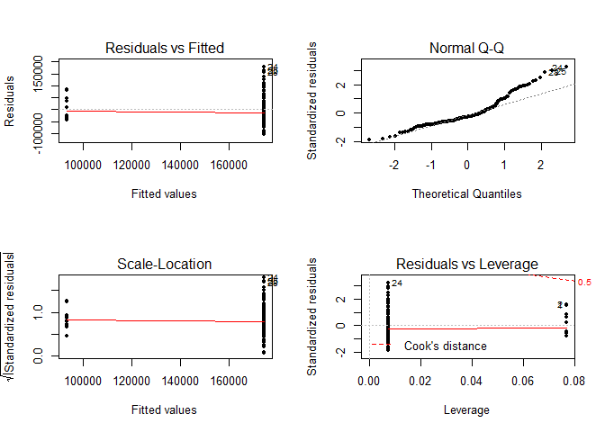

```r
#assess diagnostics
par(mfrow = c(2,2))
plot(slr1, pch = 20)
```

Based on the plots above, there might be an issue with non-constant variance. The Residuals vs. Fitted Plot indicates wide variability for observations with ‘large’ fitted values and much narrower variability for observations with ‘small’ fitted values. The QQ plot is not quite linear either, so it might be time to start thinking about tweaking our model by either transforming it or considering more variables.

## Multiple Regression: Models with more than 1 variable

Maybe you decide that the presence/absence of a garage isn’t enough information to accurately predict a home’s sales price. You want to fit a model that contains more than just a single variable. That moves us into the world of multiple linear regression. Here, we can examine many predictor variables at a time. The way you implement MLR in R is the same as you would in a single variable regression, but you can use the + sign to add variables to the model formula.

```r
#multilple linear regression
mlr1 <- lm(Price ~ ACRES + Total_HeatedSqFtV + BEDROOM +
             Full.Bath + Garage + Month, data = mcdat_r[,-1])
```

Remember, it’s always a good idea to check diagnostics! These are the same as in the linear model case. Thankfully, these look pretty good! The QQ-plot is nearly perfectly linear and the Residuals vs. Fitted plot shows even spread for all fitted values. This model appears to be pretty reasonable.

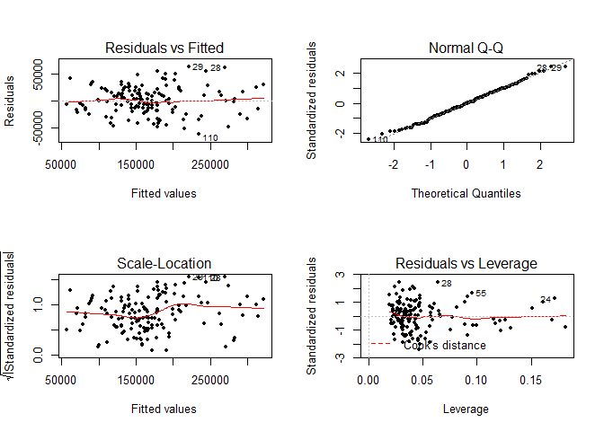

```r
#diagnostics
par(mfrow = c(2,2))
plot(mlr1, pch = 20)
```

## Model Interpretation:

Now that you have a reasonably good model, it’s time to use it! Here’s the results from the model. Which effects are ‘statistically significant?’

```r
#model summary
pander(summary(mlr1))
```

|  | Estimate | Std. Error | t value | Pr(>\|t\|) |
| --- | --- | --- | --- | --- |
| **(Intercept)** | -62376 | 14982 | -4.163 | 5.516e-05 |
| **ACRES** | 97851 | 47412 | 2.064 | 0.04092 |
| **Total_HeatedSqFtV** | 159.9 | 8.583 | 18.63 | 2.195e-39 |
| **BEDROOM** | -14276 | 4557 | -3.133 | 0.002117 |
| **Full.Bath** | 5637 | 4616 | 1.221 | 0.2241 |
| **Garage** | 22041 | 8658 | 2.546 | 0.01201 |
| **Month** | 1514 | 710.5 | 2.13 | 0.03492 |

Fitting linear model: Price ~ ACRES + Total_HeatedSqFtV + BEDROOM + Full.Bath + Garage + Month

| Observations | Residual Std. Error | $R^2$ | Adjusted $R^2$ |
| --- | --- | --- | --- |
| 144 | 26602 | 0.8124 | 0.8042 |

If you said “darn-near everything”, you’re on the right track. To determine which features are ‘statistically significant’ (meaning that we have strong evidence that they play an important role in affecting sales price), look at the P-value (denoted Pr(>t)). Variables that have p-values less than 0.05 are usually considered ‘significant’.

## Visulizing Models

One nice tool for visualizing estimated coefficients can be found in the Effects package in R (Fox, 2009). These show the estimated effect of each predictor on the response variable, and they can be very handy for explaining a model’s results to a client/customer. They are also handy for us in interpreting which how each predictor affects the response.

Here’s an example:

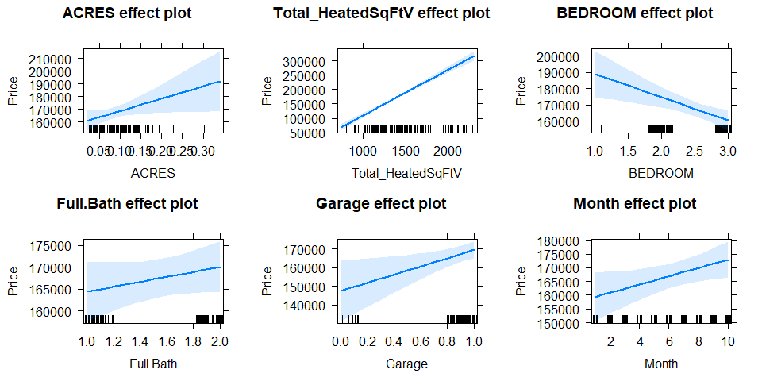

```r
#visualize the model: Effects Plots plot the estimated mean at each level of the group
library(effects)
plot(allEffects(mlr1))
```

## Making Predictions

Finally, we’ve fit a model, checked diagnostics, and interpreted some of the most salient results. Now we are ready to make some predictions!

We have a set of new homes for which we want to make predictions about house price. You can explore it here:

```r
datatable(mcdat.predict[,-c(6,11,12)], options = list(pageLength = 5, scrollX = 75))
```

|  | PROPERTYUSE | PARCELNUMBER | SITUS_ADDRESS | NEIGHBORHOOD | Account.Number | SIBPARCEL | TITLENO | NEIGHBORHOOD.Desc. | Date | Price | Verified | Validity | Reception | Doc..Type | Prop.Type | SALE_PROPERTYTYPE | SALE_DOCUMENTTYPEVALUE | ECONOMICAREA | Prop.Use.Desc. | LATITUDE | LONGITUDE | ACRES | Total_HeatedSqFtV | Price.by.Heated.SQFT | Book | Page | numberofBuildings | ArchConcat | Min_EFFECTIVEYEARBUILT | … |
| --- | --- | --- | --- | --- | --- | --- | --- | --- | --- | --- | --- | --- | --- | --- | --- | --- | --- | --- | --- | --- | --- | --- | --- | --- | --- | --- | --- | --- | --- | --- |
| 146 | 1003 | 2945-121-01-042 | 2548 EL CORONA DR | 54.16 | R059766 |  |  | Corona Del Rey(tnhs) | 8/26/2010 | 205000 | True | QF | 2544446 | WD | IMPROVED | I | WARRANTY DEED | GJ North Area | Townhouse | 39.09056338 | -108.5368826 | 0.075 | 1530 | 134 |  |  | 1 | -TOWNHSE 1-Sty- | 1992 | … |
| 147 | 1003 | 2945-121-01-043 | 2540 EL CORONA DR | 54.16 | R059767 |  |  | Corona Del Rey(tnhs) | 12/2/2010 | 179000 | True | QF | 2555219 | WD | IMPROVED | I | WARRANTY DEED | GJ North Area | Townhouse | 39.09042952 | -108.5368845 | 0.075 | 1492 | 120 |  |  | 1 | -TOWNHSE 1-Sty- | 1992 | … |
| 148 | 1003 | 2945-174-46-016 | 2384 RIDGE CIRCLE DR #16 | 56.07 | R066707 |  |  | Entrada Townhomes | 1/27/2012 | 195000 | True | QF | 2599975 | WD | IMPROVED | I | WARRANTY DEED | Redlands | Townhouse | 39.06326752 | -108.6115431 | 0.063 | 1593 | 122.4 |  |  | 1 | -TOWNHSE 1-Sty- | 1999 | … |
| 149 | 1003 | 2945-201-12-016 | 386 E VALLEY CIR #A | 56.1 | R067728 |  |  | The Ridges Townhomes | 1/30/2012 | 128000 | True | QF | 2599722 | SWD | IMPROVED | I | SPECIAL WARRANTY DEED | Redlands | Townhouse | 39.06058589 | -108.6101995 | 0.1 | 1576 | 81.2 |  |  | 1 | -TOWNHSE 1-Sty- | 1989 | … |
| 150 | 1003 | 2945-201-63-010 | 362 CLIFF VIEW DR | 56.18 | R067798 | 0000-000-00-000 |  | Shadow Run Twnhms | 5/11/2012 | 262000 | True | QF | 2611861 | SWDJT | IMPROVED | I | SPECIAL WARRANTY DEED | Redlands | Townhouse | 39.05795048 | -108.6098693 | 0.047 | 2586 | 101.3 |  |  | 1 | -TOWNHSE 1-Sty- | 2007 | … |
| 151 | 1003 | 2945-201-63-012 | 358 CLIFF VIEW DR | 56.18 | R067800 | 0000-000-00-000 |  | Shadow Run Twnhms | 1/20/2012 | 225000 | True | QF | 2598427 | WDJT | IMPROVED | I | WARRANTY DEED JOINT TENANTS | Redlands | Townhouse | 39.05783649 | -108.6101762 | 0.047 | 2586 | 87 |  |  | 1 | -TOWNHSE 1-Sty- | 2007 | … |
| 152 | 1003 | 2945-201-63-016 | 350 CLIFF VIEW DR | 56.18 | R067804 | 0000-000-00-000 |  | Shadow Run Twnhms | 4/11/2011 | 246500 | True | QV | 2569114 | SWDJT | IMPROVED | I | SPECIAL WARRANTY DEED | Redlands | Townhouse | 39.05747878 | -108.6106697 | 0.047 | 2586 | 95.3 |  |  | 1 | -TOWNHSE 1-Sty- | 2006 | … |
| 153 | 1003 | 2945-201-63-025 | 333 CLIFF VIEW DR | 56.18 | R067813 | 0000-000-00-000 |  | Shadow Run Twnhms | 1/4/2011 | 300000 | True | QF | 2559748 | WDJT | IMPROVED | I | WARRANTY DEED JOINT TENANTS | Redlands | Townhouse | 39.05833452 | -108.6105918 | 0.047 | 2586 | 116 |  |  | 1 | -TOWNHSE 1-Sty- | 2008 | … |
| 154 | 1003 | 2945-201-63-032 | 336 CLIFF VIEW DR | 56.18 | R067820 | 0000-000-00-000 |  | Shadow Run Twnhms | 5/18/2012 | 243500 | True | QF | 2611874 | WD | IMPROVED | I | WARRANTY DEED | Redlands | Townhouse | 39.05805255 | -108.6102343 | 0.047 | 2586 | 94.2 |  |  | 1 | -TOWNHSE 1-Sty- | 2008 | … |
| 155 | 1003 | 2945-233-18-001 | 1714 DOLORES ST | 58.03 | R069336 | 2 - - - |  | Townhouse | 9/14/2011 | 69231 | True | QV | 2584933 | SWD | IMPROVED | I | SPECIAL WARRANTY DEED | Orchard Mesa | Townhouse | 39.04972233 | -108.5643626 | 0.048 | 1272 | 54.4 |  |  | 1 | -TOWNHSE 1-Sty- | 1987 | … |

[output cut: 8 more lines]

```r
predictions <- predict(mlr1, newx = mcdat.predict)
length(predictions)
```

```
## [1] 144
```

```r
#plot(mcdat.predict$Total_HeatedSqFtV, predictions)
```